# Designing a Tax Credit Policy for Work Loss Days: A Predictive Modeling and Microsimulation Approach

PPOL 6819 | Advanced Data Science | Final Project

Author

Jasmine Jha, Stephanie Jamilla, Maleeha Hameed

## Preliminaries

```r
library(tidyverse)
library(tidymodels)
library(haven)
library(here)
library(ipumsr)
library(janitor)
library(srvyr)
library(knitr)
library(vip)
```

## 1. Background

### 1.1 Problem Statement

The United States is the only country in the OECD, and one of only six countries in the world, to not offer national paid parental leave (“Paid Family Leave Across OECD Countries” 2022). Currently, 13 states and DC have mandatory paid family leave policies, all of which use social insurance models in which employers and employees pay into the program in order to access wages for leave (“What’s on the Table? A Review of Federal Paid Family Leave Proposals” 2025a). Discussion about paid family leave typically centers on parental leave, but these state policies also cover personal medical leave, allowing individuals to take care of their own serious health conditions. This is particularly important for individuals with chronic or serious health conditions who have to miss work and have no guarantee that their workplace will offer paid sick leave. Thus, such individuals may not earn any money for missed work days and thus have lower overall earnings compared to healthy individuals.

### 1.2 Policy Solution

This project proposes implementing a federal policy that mandates paid family leave, focusing on paid personal medical leave. The policy is based on current state policies–for example, states typically require that employees be granted up to 13 weeks of personal medical leave and have a maximum weekly benefit based on statewide average weekly wages. We create a baseline policy, then make adjustments to the dollar amount eligible employees receive or other components of the policy that determine the total amount transferred to individuals.

A primary concern about family leave policies is that they would adversely affect business productivity or profit as employees would take longer time off. However, a handful of studies on the effects of the policy in California and New York demonstrate that the policy has actually had a positive effect on employee productivity and no significant impact on employee performance [Bartel et al. (2023a)](Bartel et al. 2023b).

## 2. Empirical Methodology

### 2.1 Data

#### Data Description

We used the 2018 dataset from the National Health Interview Survey, available on the IPUMS website (Blewett et al., n.d.). This dataset includes 72,831 observations and 1,503 variables. We selected the 2018 dataset because it offers a relatively large number of observations alongside a wide range of variables compared to later (i.e., more recent) years.

The 1503 variables pertained to household and individual level information on demographic characteristics, socioeconomic status, general health status, mortality, specific diseases, health conditions, health behaviours, health education, medical care and access, health insurance, mental health, vaccinations history, alternative health, and social determinants of health.

```r
#| output: false
#| warning: false
#| message: false

ddi <- read_ipums_ddi(here("data", "nhis_00004.xml"))
full_data <- read_ipums_micro(ddi)
```

```
Use of data from IPUMS NHIS is subject to conditions including that users should cite the data appropriately. Use command `ipums_conditions()` for more details.
```

#### Data Preprocessing

```r
# Cleaning Names
full_data <- full_data |>
  clean_names()

# Selecting 104 variables
work_loss <- full_data |>
  select(nhispid, age, sex, sexorien, marstleg, relate, famsize, nchild, nsibs, famkidno, famoldno, parenthere, racenew, hispeth, yrsinusg, usborn, citizen, regionbr, intervlang, educ, headstarev, headstarnow, empstat, occ, ind, hourswrk, secondjob, paidhour, paidsick, empstatwkyr, classwk2, jobsecincorp, workev, yearsonjob, mainlong, whynowk2, pooryn, incfam07on, earnings, welfmo, gotwelf, gotnewelf, gotssi, gotssiwhy, ssiapply, gotss, gotnonssdis, ssdiapply, gotdiv, gotint, gotothpen, gotwage, gotsemp, gotchsup, gotwic, wiceligible, wicflag, gotstampfam, stampmo, gotother, poverty, fsateless, fsbalanc, fshungry, fsnoteat, fsnoteatno, fsnotlast, fsrawscore, fsrunout, fsskip, fsskipno, fsstat, fsweight, ownership, lowrent, health, bmi, bedayr, hstatyr, wldayr, workvolhcset, workvolhcpat, nbhdtime, pregnantnow, pregflush, hystev, bwgtgram, dvint, docvis2w, homecare2w, phonemed, famcare10xno, mamnoflup, mamother, mamult, papev, papab3yr,psalest, psaly, psasugg, mortelig, mortstat, mortdody, mortucodld)


# Recoding for NA values - there were no values to change
work_loss <- work_loss |>
  mutate(famsize = case_when(
    famsize == 99 ~ 0,
    famsize == 98 ~ NA_real_,
    TRUE ~ famsize
  ))

# Recoding for NA values
work_loss <- work_loss |>
  mutate(across(c(famkidno, famoldno, hourswrk, welfmo), ~ifelse(. == 98, NA, .)))

work_loss <- work_loss |>
  mutate(across(c(hourswrk, welfmo), ~ifelse(. %in% c(97, 99), NA, .)))

work_loss <- work_loss |>
  mutate(across(c(bedayr, wldayr), ~ifelse(. %in% c(997, 998, 999), NA, .)))

work_loss <- work_loss |>
  mutate(bedayr = ifelse(bedayr == 996, 0, bedayr),
         wldayr = ifelse(wldayr == 996, 0, wldayr))

work_loss <- work_loss |>
  mutate(bwgtgram = ifelse(bwgtgram %in% c(9997, 9998, 9999), NA, bwgtgram))

work_loss <- work_loss |>
  mutate(famcare10xno = ifelse(famcare10xno == 9, NA, famcare10xno))

# Transform all categorical variables to factor
## Creating custom function
make_factor <- function(variable) {

  work_loss |>
    mutate(across(c(variable), as.factor))

}

## Creating a list of all categorical variable names
vars <- select(.data = work_loss, -nhispid, -age, -famsize, -famkidno, -famoldno, -hourswrk, -welfmo, -bmi, -bedayr, -wldayr, -bwgtgram, -famcare10xno)
list <- (colnames(vars))

## Iterating the function over each categorical variable
work_loss <- make_factor(variable = list)
```

1. **Standardization of variable names:** We standardized all variable names to ensure consistency and facilitate downstream processing. This involved converting all names to lowercase and replacing spaces and special characters with underscores. These modifications improved both readability and compatibility with data manipulation functions.
2. **Variable selection:** We manually reviewed and filtered the original set of 1,503 variables, reducing it to a focused subset of 104 variables. This selection excluded any variables with imputations, flags, or duplicate variants (e.g., summary or imputed versions of the same item). The final dataset includes variables from the following domains:
   - **Demographics**: age, sex, marital status
   - **Family composition**: household size, number of children, number of older adults
   - **Employment and income**: job type, hours worked, earnings, welfare receipt
   - **Health**: body mass index (BMI), days in bed due to illness, caregiving frequency

   This streamlined selection was guided by theory and relevance to the research question.
3. **Recoding special and missing values:** We cleaned the data by identifying and recoding special response codes that represented missing or invalid data in numeric variables. For example, values such as 98, 99, and 997–999 were treated as missing, while specific codes like 996 (indicating “none” or “zero”) were recoded to 0. This step ensured that all numeric fields reflected interpretable and analyzable values. Additionally, this step ensured numerical consistency and prevented skewed analysis due to placeholder codes.
4. **Conversion of categorical variables:** While many of the variables are categorical in nature, they were coded to be numeric in the NHIS. Thus, we transformed these erroneously numeric variables to factor so that they can be manipulated for dummy encoding later for the predictive models. This included responses related to employment status, education, language, and benefit receipt. This step was essential for accurate modeling and visualization, particularly for tree-based and regularized regression models.
5. **Identification of the outcome variable:** Our primary outcome variable is **`wldayr`**, representing the number of work loss days in the past 12 months. This was chosen as the outcome variable because such a model could help policymakers understand the prevalence of how injury and illness are affecting their constituency’s ability to go to work and get a sense of how a proposed family leave policy (with a focus on personal medical leave) would affect their constituency.

### 2.2 Approaches

We use two complementary machine learning approaches to explore the policy question at hand: predictive modeling and microsimulation.

#### Predictive Modeling

The first part of the project focuses on developing two predictive models to estimate the number of work loss days an individual may experience, using features such as demographics, health history, insurance coverage, and other socioeconomic factors. These models aim to help policymakers understand how illness and injury impact labor force participation, thereby informing the design of targeted policy interventions.

We employ two modeling techniques—random forests (a tree-based ensemble method) and elastic net regression (a regularized linear model that balances L1 and L2 penalties). These methods were chosen for their complementary strengths: random forests are capable of capturing nonlinear interactions and complex variable relationships, while elastic net regression offers interpretability and variable selection in high-dimensional settings. We compare their performance to identify the most effective and interpretable model for informing policy design. Additional methodological details are provided in Section 3.2.

#### Microsimulation

The second part of the project involves the creation of a microsimulation using a built-in microsimulation calculator to implement a proposed tax credit or cash transfer policy.

We begin by defining the policy parameters based on existing state family leave policies and proposed federal policies. The microsimulation allows us to estimate the impact of the policy at the individual and household level, simulating outcomes under different eligibility rules and benefit structures.

In the third step, we systematically vary key parameters of the policy to assess the distributional effects of these changes. This sensitivity analysis helps identify equity concerns and possible unintended consequences such as employers reducing paid sick leave offerings in response to the new government provision.

### 2.3 Limitations

- **Variable selection:** We reduced the raw dataset to 104 variables based on a combination of intuition and theoretical considerations, excluding variables that were repetitive, imputed, or had excessive missing values. While a more principled, data-driven variable selection approach may have enhanced the predictive performance and accuracy of our microsimulation models, the full set of 1,503 variables was too unwieldy for the methods employed in this project.
- **Limited number of predictive models:** Although we would have preferred to explore a broader set of predictive models, such as XGBoost or Generalized Additive Models (GAMs), and experiment with hyperparameter tuning, computational constraints limited our ability to do so. These models, while potentially more powerful, were too resource-intensive given our available infrastructure.
- **Lack of geographical data:** Incorporating detailed geographic data would have enabled us to distinguish between state and federal policy effects in our microsimulation calculator, providing a more nuanced understanding of policy implementation. Unfortunately, the absence of such data restricted our ability to analyze these geographic variations. There was extremely broad geographic information that identified if a household is in the “northeast,” “north central/midwest,” “south,” or “west.” However, this was not a useful variable as we would not be able to understand how state and federal policies could interact or affect each other. Therefore for the microsimulation, we assume that state policies are not relevant to the distribution of funds.

## 3. Predictive Modelling

### 3.1 Setup

#### 3.1.1 Split data into testing and training data

```r
# Split the dataset
set.seed(2025)

work_loss_split <- initial_split(work_loss, prop = 0.8)

work_loss_train <- training(x = work_loss_split)
work_loss_test  <- testing(x = work_loss_split)
```

#### 3.1.2 Set up resampling for model selection

```r
# Set crossvalidation
work_loss_folds <- vfold_cv(data = work_loss_train, v = 10)
```

### 3.2 Create Candidate Models

#### 3.2.1 Random Forests

Random Forests is a tree-based model that uses bagging, which is an ensembling method. The model considers random sections of the dataset and a subset of predictors to train each regression tree. This method was chosen based on past experience with this nonparametric model performing well (i.e., achieving a relatively low RMSE value) compared to other models.

However, one downside is that random forests is not as easily interpretable compared to other models, such as linear regression that can offer clearer coefficients and directions between the predictors and the outcome variable. It is not easy to understand how the random forest model makes predictions across the dataset and its element of randomness further complicates interpretability.

A mtry value of 15 was chosen based on previous model running, which demonstrated that the mtry value did not vary within the top five tuning results. For the sake of faster processing, only min_n was tuned.

```r
# Create recipe
rf_rec <- recipe(formula = wldayr ~ ., data = work_loss_train) |>
  update_role(c(nhispid), new_role = "id") |>
  step_rm(has_role("id")) |>
  step_dummy(all_factor_predictors()) |>
  step_zv(all_predictors()) |>
  step_corr(all_numeric_predictors()) |>
  step_impute_mean(all_numeric_predictors()) |>
  step_naomit(wldayr)

# Baking to check number of observations and variables
data_prepped_rf <- rf_rec |>
  prep() |>
  bake(new_data = NULL)

# Create model
rf_mod <- rand_forest(
  trees = 200,
  mtry = 15,
  min_n = tune()
) |>
  set_mode(mode = "regression") |>
  set_engine(
    engine = "ranger",
    importance = "impurity",
    num.threads = 4
  )

# Create workflow
rf_wf <- workflow() |>
  add_recipe(rf_rec) |>
  add_model(rf_mod)

# Create grid
rf_grid <- grid_regular(
  min_n(range = c(1, 15)),
  levels = 5
)

# Tune grid
rf_tuning <- tune_grid(
  rf_wf,
  resamples = work_loss_folds,
  grid = rf_grid
)

# Show best tuning results
show_best(rf_tuning)
```

```
# A tibble: 5 × 7
  min_n .metric .estimator  mean     n std_err .config
  <int> <chr>   <chr>      <dbl> <int>   <dbl> <chr>
1    11 rmse    standard    7.68    10   0.342 Preprocessor1_Model4
2     4 rmse    standard    7.69    10   0.333 Preprocessor1_Model2
3     1 rmse    standard    7.69    10   0.338 Preprocessor1_Model1
4     8 rmse    standard    7.70    10   0.341 Preprocessor1_Model3
5    15 rmse    standard    7.70    10   0.339 Preprocessor1_Model5
```

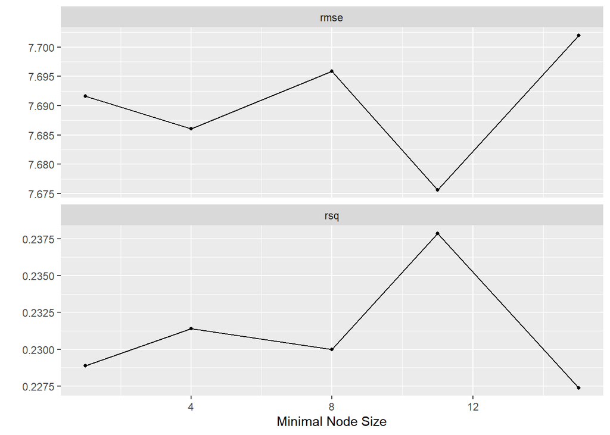

```r
# Visualize tuning results
autoplot(rf_tuning)
```

The best RMSE is 7.68 with a min_n value of 11. This may be a bit higher than ideal, but a good metric to have in order to compare it with the elastic net model.

Finalizing the workflow based on the best hyperparameters:

```r
# Finalize workflow
rf_tuned_wf <-
  rf_wf |>
  tune::finalize_workflow(tune::select_best(x = rf_tuning, metric = "rmse"))

# Fit final workflow
rf_resamples <- rf_tuned_wf |>
  fit_resamples(resamples = work_loss_folds)

# Collect metrics
rf_resamples |>
  collect_metrics()
```

```
# A tibble: 2 × 6
  .metric .estimator  mean     n std_err .config
  <chr>   <chr>      <dbl> <int>   <dbl> <chr>
1 rmse    standard   7.68     10  0.339  Preprocessor1_Model1
2 rsq     standard   0.233    10  0.0131 Preprocessor1_Model1
```

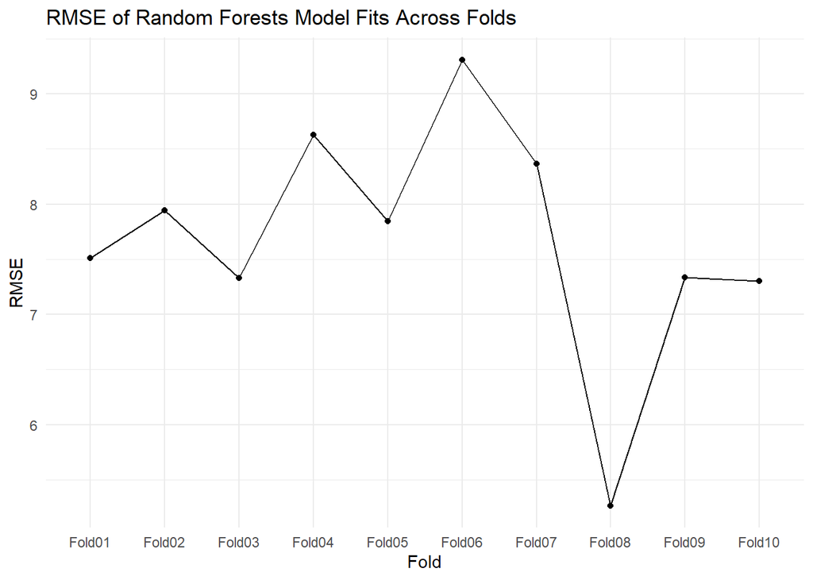

```r
rf_rmse_plot <- collect_metrics(
  rf_resamples,
  summarize = FALSE) |>
  filter(.metric == "rmse") |>
  ggplot(mapping = aes(x = id, y = .estimate, group = .metric)) +
  geom_point() +
  geom_line() +
  theme_minimal() +
  labs(
    title = "RMSE of Random Forests Model Fits Across Folds") +
  xlab("Fold") +
  ylab("RMSE")

rf_rmse_plot
```

#### 3.2.1 Elastic Net Regression

This model uses regularization, which is a powerful technique for parametric regression models. Regularization, or penalization, allows linear regression to work with very wide data, to generate stable estimates for data with multicollinearity, and to perform feature selection.

Elastic net regression combines ridge regression and LASSO regression. It has two hyperparameters, λ1 and λ2. Sometimes the hyperparameters are λ and mixture, which determines how much of λ to apply to each penalty (i.e. mixture = 0 is ridge regression and mixture = 1 is LASSO regression).

We used this model as it can work with datasets with a large number of variables, generate stable esitmates for data with multicollinearity, perform feature selection, but in a less dramatic fashion than LASSO regression

```r
# Create recipe
enet_rec <- recipe(wldayr ~ ., data = work_loss_train) |>
  update_role(c(nhispid), new_role = "ID") |>
  step_rm(has_role("ID")) |>
  step_dummy(all_factor_predictors()) |>
  step_zv(all_predictors()) |>
  step_corr(all_numeric_predictors()) |>
  step_impute_mean(all_numeric_predictors()) |>
  step_naomit(wldayr) |>
  step_normalize(all_predictors())

# Create model
enet_mod <- linear_reg(penalty = tune(), mixture = tune()) |>
  set_mode(mode = "regression") |>
  set_engine(engine = "glmnet")

# Create workflow
enet_wf <- workflow() |>
  add_recipe(recipe = enet_rec) |>
  add_model(spec = enet_mod)

# Create grid
enet_grid <- grid_regular(
  penalty(),
  mixture(),
  levels = 5
)

# Tune grid
enet_tuning <- tune_grid(
  enet_wf,
  resamples = work_loss_folds,
  grid = enet_grid
)

# Identify best tuning results
show_best(enet_tuning)
```

```
# A tibble: 5 × 8
       penalty mixture .metric .estimator  mean     n std_err .config
         <dbl>   <dbl> <chr>   <chr>      <dbl> <int>   <dbl> <chr>
1 0.00316         1    rmse    standard    8.01    10   0.313 Preprocessor1_Mod…
2 0.00316         0.75 rmse    standard    8.02    10   0.313 Preprocessor1_Mod…
3 1               0    rmse    standard    8.02    10   0.318 Preprocessor1_Mod…
4 0.00316         0.5  rmse    standard    8.02    10   0.312 Preprocessor1_Mod…
5 0.0000000001    0    rmse    standard    8.02    10   0.314 Preprocessor1_Mod…
```

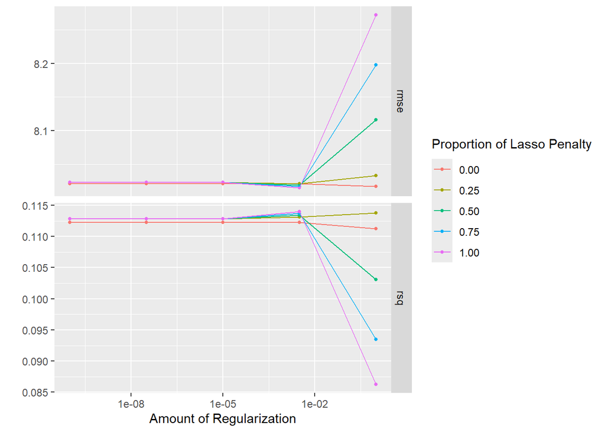

```r
# Visualize tuning results
autoplot(enet_tuning)
```

The RMSE calculated is 8.01. This shows that regularization does not help much in this case. This makes sense because the regression specification is parsimonious and deliberate.

```r
# Finalize workflow
enet_tuned_wf <-
  enet_wf |>
  tune::finalize_workflow(tune::select_best(x = enet_tuning, metric = "rmse"))

# Fit final workflow
enet_resamples <- enet_tuned_wf |>
  fit_resamples(resamples = work_loss_folds)

# Collect metrics
enet_resamples |>
  collect_metrics()
```

```
# A tibble: 2 × 6
  .metric .estimator  mean     n std_err .config
  <chr>   <chr>      <dbl> <int>   <dbl> <chr>
1 rmse    standard   8.01     10  0.313  Preprocessor1_Model1
2 rsq     standard   0.114    10  0.0106 Preprocessor1_Model1
```

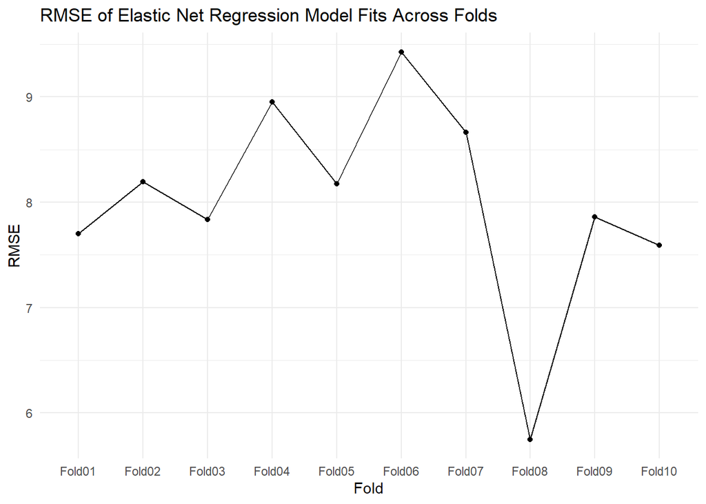

```r
enet_rmse_plot <- collect_metrics(
  enet_resamples,
  summarize = FALSE) |>
  filter(.metric == "rmse") |>
  ggplot(mapping = aes(x = id, y = .estimate, group = .metric)) +
  geom_point() +
  geom_line() +
  theme_minimal() +
  labs(
    title = "RMSE of Elastic Net Regression Model Fits Across Folds") +
  xlab("Fold") +
  ylab("RMSE")

enet_rmse_plot
```

### 3.3 Model Comparison

```r
# Compile results from both models

bind_rows(
  "Random forest" = collect_metrics(rf_resamples) |> filter(.metric == "rmse"),
  "Elastic net regression" = collect_metrics(enet_resamples) |> filter(.metric == "rmse"),
  .id = "model"
)
```

```
# A tibble: 2 × 7
  model                  .metric .estimator  mean     n std_err .config
  <chr>                  <chr>   <chr>      <dbl> <int>   <dbl> <chr>
1 Random forest          rmse    standard    7.68    10   0.339 Preprocessor1_M…
2 Elastic net regression rmse    standard    8.01    10   0.313 Preprocessor1_M…
```

Random forest has a relatively better RMSE compared to the elastic net model. Therefore, we fit the data on the random forest model and create predictions based on the testing data.

```r
# Select the best resamples via select_best
model_best <- rf_resamples |>
  select_best(metric = "rmse")

# Finalize the workflow with finalize_workflow
model_final <- finalize_workflow(
  rf_tuned_wf,
  parameters = model_best
)

# Fit the model on all the data
model_final_fit <-
  model_final |>
  last_fit(work_loss_split)

# Collect metrics for RMSE
kable(model_final_fit |>
  collect_metrics() |>
  filter(.metric == "rmse"))
```

| .metric | .estimator | .estimate | .config |
| --- | --- | --- | --- |
| rmse | standard | 6.819991 | Preprocessor1_Model1 |

```r
# Make predictions with the testing data
model_predictions <- bind_cols(
  work_loss_test,
  predict(object = extract_workflow(model_final_fit),
          new_data = work_loss_test)
)

# Display the first 10 predictions against the actual values
select(model_predictions, wldayr, starts_with(".pred"))
```

```
# A tibble: 14,567 × 2
   wldayr   .pred
    <dbl>   <dbl>
 1      0 0
 2      0 0
 3      0 0
 4      0 0
 5      0 1.93
 6      0 0.257
 7      0 2.57
 8      0 0.00280
 9      0 0
10      0 0
# ℹ 14,557 more rows
```

```r
# Interrogate which values were incorrectly predicted to the nearest tenth

kable(model_predictions |>
  select(wldayr, .pred) |>
  mutate(.pred = round(model_predictions$.pred, 1),
         wldayr = round(model_predictions$wldayr, 1),
         correct = if_else(.pred == wldayr, "Yes", "No"
         )) |>
  count(correct))
```

| correct | n |
| --- | --- |
| No | 4965 |
| Yes | 9592 |
| NA | 10 |

Clearly the model is not perfect. While it did predict more work loss day values correctly than incorrectly, better performance should be achieved before implementation of this model. Some ways to improve the model are explored in the conclusion of this project. At the highest level, adding in additional variables would likely have improved the model or selecting different variables that are better predictors of work loss days.

### 3.4 Variable Importance

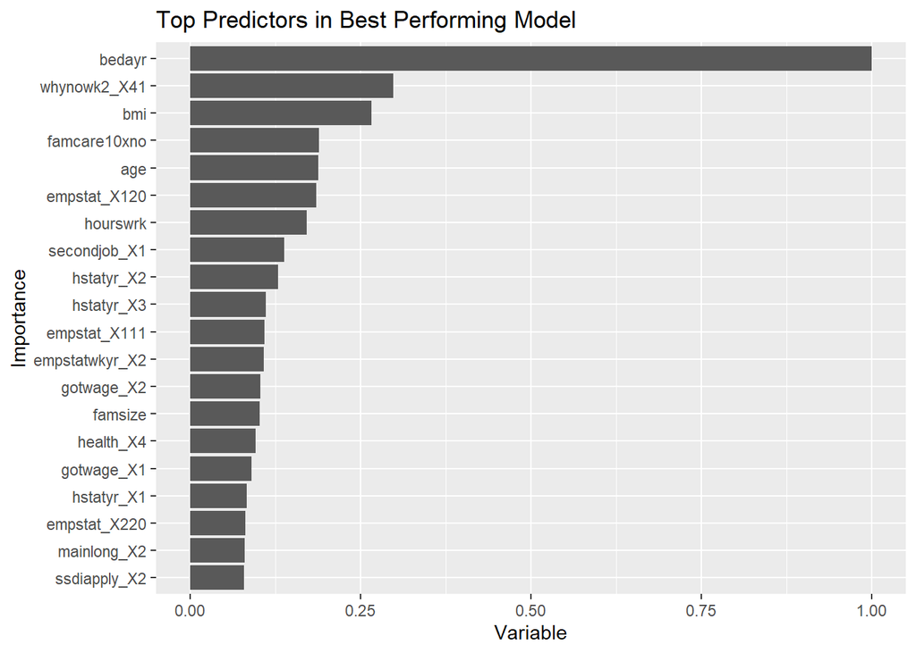

```r
model_final_fit |>
  extract_fit_parsnip() |>
  vip(num_features = 20) %>%
  .$data |>
  mutate(
    Importance = Importance / max(Importance),
    Variable = fct_reorder(.x = Importance, .f = Variable)
  ) |>
  ggplot(aes(Importance, Variable)) +
  geom_col() +
  labs(title = "Top Predictors in Best Performing Model") +
  ylab("Importance") +
  xlab("Variable")
```

The most important variable in the model is bedayr, which is the number of days in the past year that a person was in bed for more than half the day. This, of course, makes sense since people who have to work in person cannot go to work if they are bedridden.

The second important variable is one of the dummy encoded variables (“whynowk2”) which is a categorical variable that contains information about why someone missed work last week. This makes sense as well, given that if someone missed work previously, they could have done so due to health reasons, which would affect the number of days they missed work.

BMI is the third most important variable, which is likely a proxy for overall health of the individual. The fourth most important variable is famcare10xno, which is the number of family members who received care 10 or more times in the past year. This is interesting since it’s about overall family members instead of individuals, while work loss days is meant to be about taking a day off of work for an individual’s health. Lastly, age is the fifth most important predictor - perhaps those of older age take more days off of work because they are more prone to illness and injury.

## 4. Microsimulation

We developed a microsimulation using a nationally representative dataset to evaluate the impact of a proposed cash transfer policy aimed at supporting individuals experiencing work loss. The core objective is to translate the policy’s eligibility criteria and benefit formula into individual-level estimates, allowing us to assess who benefits, by how much, and how the benefits are distributed across income groups.

The simulation begins by defining key policy parameters:

1. The threshold of work loss days required for eligibility
2. The reimbursement rate per week or day
3. Any caps on total reimbursement
4. Income-based or poverty-based eligibility conditions

We then implement these rules to each individual wihin the full data set and generate estimates of their potential reimbursement under different policy designs. By weighting these estimates, we can calculate population-level outcomes such as the mean reimbursement and the number of eligible individuals, as well as explore differences by income group.

```r
# For microsimulation
full_data <- full_data |>
  filter(!wldayr %in% c(996,997, 998, 999))
```

### 4.1 Counterfactual

The first simulation represents a counterfactual scenario with broad eligibility, essentially modelling what reimbursement would look like under a policy where all are eligible:

1. Eligibility: Anyone with more than 0 work loss day is eligible for reimbursement.
2. Benefit formula:
   - Individuals with less than or equal to 84 work loss days receive a reimbursement proportional to their number of lost days. This reflects the FAMILY Act, which is a Democratic party-backed proposal that has been introduced in Congress most recently in 2023-24. If passed, it would provide 12 weeks of paid family leave (“What’s on the Table? A Review of Federal Paid Family Leave Proposals” 2025a).
   - Reimbursement equals the number of work loss days multiplied by the weekly reimbursement rate divided by 7.
   - Individuals with greater than 84 work loss days receive a capped reimbursement equal to the full rate for 12 weeks.
   - The national median weekly earnings level of full-time wage and salary workers Q1 of 2025 were used as the weekly reimbursement rate. This results in a weekly reimbursement rate of $1194 “Usual Weekly Earnings Summary” (2025). This reflects how current state policies determine the maximum weekly benefit based on statewide average wages (“What’s on the Table? A Review of Federal Paid Family Leave Proposals” 2025b). Using the U.S. Bureau of Labor Statistics median rate gives us a comparable way to simulate what reimbursements could look like at the national level.

This simulation calculates reimbursement amounts for every individual, regardless of income or poverty status, and uses survey weights (PERWEIGHT) to estimate the mean reimbursement and the total eligible population.

```r
#' Baseline/Counterfactual Family Leave Policy Calculator
#'
#' @param wldayr A numeric value for number of days missed work due to illness
#' @param perweight A numeric value for the survey weight
#' @param reimbursement_rate A numeric value for the weekly reimbursement rate
#' @param num_weeks A numeric value for the max number of weeks reimbursed
#'
#' @return A dataframe
#'

simulate_reimbursement_cf <- function(wldayr, perweight, reimbursement_rate, num_weeks) {

  eligible <- (wldayr > 0)

  reimbursement <- numeric(length(wldayr))

  below <- eligible & (wldayr <= 84)
  above <- eligible & (wldayr > 84)

  reimbursement[below] <- (wldayr[below]) * (reimbursement_rate / 7)
  reimbursement[above] <- reimbursement_rate * num_weeks

  data.frame(
    id = seq_along(wldayr),
    reimbursement = reimbursement,
    perweight = perweight,
    income = full_data$incfam07on
  )
}
```

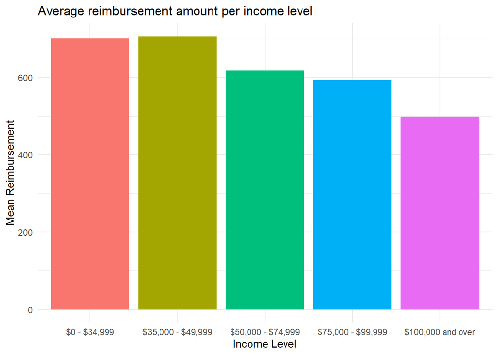

```r
simulated_data_cf <- simulate_reimbursement_cf(
  wldayr = full_data$wldayr,
  perweight = full_data$perweight,
  reimbursement_rate = 1194,
  num_weeks = 12
)


weighted_data_cf <- simulated_data_cf |>
  as_survey_design(weights = perweight)


result_cf <- weighted_data_cf |>
  summarise(
    mean_reimbursement = survey_mean(reimbursement),
    num_eligible = survey_total(as.numeric(reimbursement > 0))
  )

# Graph to show mean reimbursement per family income level
simulated_data_cf |>
  group_by(income) |>
  filter(income < 96 & income != 10 & income != 21) |>
  mutate(mean_reimbursement = mean(reimbursement),
         income = case_when(
           income == 11 ~ "$0 - $34,999",
           income == 12 ~ "$35,000 - $49,999",
           income == 22 ~ "$50,000 - $74,999",
           income == 23 ~ "$75,000 - $99,999",
           income == 24 ~ "$100,000 and over"
         ),
    income = factor(income, levels = c("$0 - $34,999", "$35,000 - $49,999", "$50,000 - $74,999", "$75,000 - $99,999", "$100,000 and over"))) |>
  count(mean_reimbursement) |>
  ggplot() +
  geom_col(aes(x = income, y = mean_reimbursement, fill = income)) +
  labs(title = "Average reimbursement amount per income level",
      x = "Income Level",
      y = "Mean Reimbursement") +
  theme_minimal() +
  theme(legend.position = "none")
```

The bar chart above shows the average reimbursement per income level. This is under the simulated counter-factual reimbursement model.

We see that people earning between $0 to $34999 and $3500 to $49999 receive the highest average reimbursement of about $700. People earning $100000 and over received the lowest reimbursement of about $500. Under this policy, lower income groups received higher average reimbursement than higher income, despite equal reimbursement caps. This reflects that lower-income workers had more work loss days.

### 4.2 Adjusted Policy Model

The second simulation implements a targeted policy with stricter eligibility rules, reflecting a more realistic intervention:

1. Eligibility:
   - Individuals must have at least 28 work loss days. This proposal would involve requiring employers to pay the first 28 days (4 weeks) of family leave. This would lower the burden and responsibility of the government to pay out the full reimbursement.
   - Must fall below a specified poverty threshold (families make below 5x the poverty threshold).
2. Benefit formula:
   - Eligible individuals with less than or equal to 91 work loss days are reimbursed only for days beyond the 28-day threshold. 91 work loss days was decided based on the average number of weeks that states provide for personal medical leave under the paid family leave policies (“State Paid Family Leave Laws Across the u.s.” 2024).
   - Reimbursement = (work loss days−28) × (reimbursement rate / 7)
   - Individuals with greater than 91 work loss days receive a capped reimbursement equal to the rate for 9 weeks.
   - The same reimbursement rate of $1194 per week is used as in the counterfactual.

As in the counterfactual, we estimate mean reimbursement and number eligible using survey weights (PERWEIGHT), and visualize results by income level.

```r
#' Alternative Family Leave Policy Calculator
#'
#' @param wldayr A numeric value for number of days missed work due to illness
#' @param poverty A numeric value that indicates a family's income to poverty threshold ratio
#' @param perweight A numeric value for the survey weight
#' @param reimbursement_rate A numeric value for the weekly reimbursement rate
#' @param num_weeks A numeric value for the max number of weeks reimbursed
#'
#' @return A dataframe
#'

simulate_reimbursement <- function(wldayr, poverty, perweight, reimbursement_rate, num_weeks) {
  eligible <- (wldayr > 28 & (poverty < 37 | poverty == 38))

  reimbursement <- numeric(length(wldayr))

  below <- eligible & (wldayr <= 91)
  above <- eligible & (wldayr > 91)

  reimbursement[below] <- (wldayr[below] - 28) * (reimbursement_rate / 7)
  reimbursement[above] <- reimbursement_rate * num_weeks

  data.frame(
    id = seq_along(wldayr),
    reimbursement = reimbursement,
    perweight = perweight,
    income = full_data$incfam07on
  )
}
```

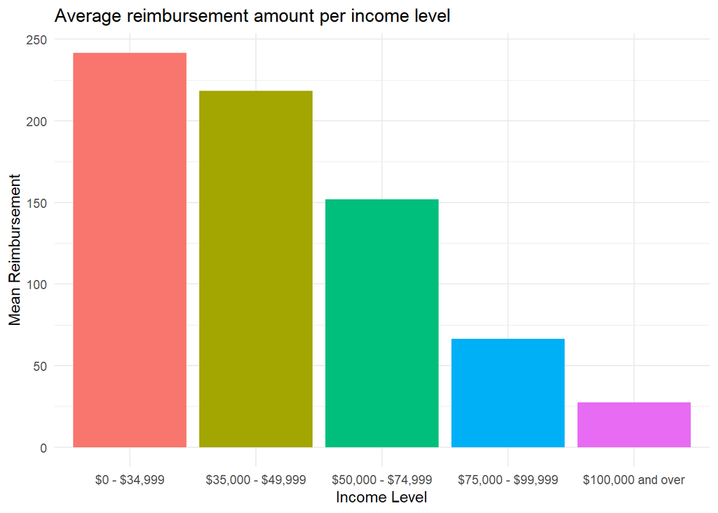

```r
simulated_data_custom_rate <- simulate_reimbursement(
  wldayr = full_data$wldayr,
  poverty = full_data$poverty,
  perweight = full_data$perweight,
  reimbursement_rate = 1194,
  num_weeks = 9
)

weighted_data <- simulated_data_custom_rate |>
  as_survey_design(weights = perweight)


result_final <- weighted_data |>
  summarise(
    mean_reimbursement = survey_mean(reimbursement),
    num_eligible = survey_total(as.numeric(reimbursement > 0))
  )

# Graph to show mean reimbursement per family income level
simulated_data_custom_rate |>
  group_by(income) |>
  filter(income < 96 & income != 10 & income != 21) |>
  mutate(mean_reimbursement = mean(reimbursement),
         income = case_when(
           income == 11 ~ "$0 - $34,999",
           income == 12 ~ "$35,000 - $49,999",
           income == 22 ~ "$50,000 - $74,999",
           income == 23 ~ "$75,000 - $99,999",
           income == 24 ~ "$100,000 and over"
         ),
    income = factor(income, levels = c("$0 - $34,999", "$35,000 - $49,999", "$50,000 - $74,999", "$75,000 - $99,999", "$100,000 and over"))) |>
  count(mean_reimbursement) |>
  ggplot() +
  geom_col(aes(x = income, y = mean_reimbursement, fill = income)) +
  labs(
    title = "Average reimbursement amount per income level",
    x = "Income Level",
    y = "Mean Reimbursement"
  ) +
  theme_minimal() +
  theme(legend.position = "none")
```

In this case the reimbursements cap is lowered from 12 weeks to 9 weeks. Eligibility is also narrowed based on poverty score. People in income level $0 to $34999 have the highest mean reimbursement of about $240. and people in income level $100000 and over have the lowest mean reimbursement of about $30.

Lower income group still has the high average reimbursement but it is lower than the counterfactual model. This adjusted policy model targets reimbursements towards lower-income individuals by incurring lower total expenditure by the government.

### 4.3 Comparison of Microsimulation Models

The key difference between the models is in the way we define eligibility and by how much they receive.

The counterfactual model is universal, it includes anyone with any work loss, regardless of poverty level or severity, resulting in a larger eligible population and higher overall expenditure. On the other hand, the adjusted policy model is targeted, it restricts benefits to lower-income individuals who have experienced substantial work loss, leading to a smaller eligible group and lower total reimbursement.

Both models provide insights into the distributional effects of the policy. While the counterfactual shows the maximum reach of benefits, the adjusted policy model reveals how narrowing eligibility shifts support toward the most disadvantaged but reduces total expenditure.

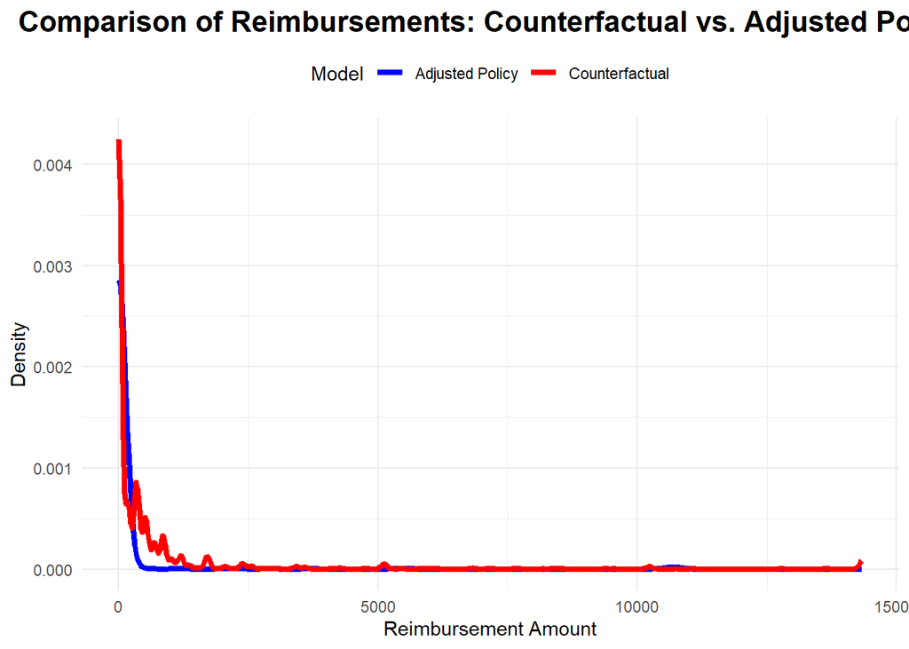

```r
simulated_data_cf$model <- "Counterfactual"
simulated_data_custom_rate$model <- "Adjusted Policy"

comparison_data <- rbind(simulated_data_cf, simulated_data_custom_rate)

comparison_data <- comparison_data |>
  select(reimbursement, model)

summary_stats <- comparison_data |>
  group_by(model) |>
  summarise(
    mean_reimbursement = mean(reimbursement),
    sd_reimbursement = sd(reimbursement),
    min_reimbursement = min(reimbursement),
    max_reimbursement = max(reimbursement)
  )


ggplot(comparison_data, aes(x = reimbursement, color = model)) +
  geom_line(stat = "density", size = 1.5) +
  scale_color_manual(values = c("blue", "red")) +
  labs(
    title = "Comparison of Reimbursements: Counterfactual vs. Adjusted Policy",
    x = "Reimbursement Amount",
    y = "Density",
    color = "Model"
  ) +
  theme_minimal() +
  theme(
    legend.position = "top",
    plot.title = element_text(hjust = 0.5, size = 16, face = "bold")
  )
```

The graph above, compares the distribution of reimbursement under the counter-factual and adjusted policy model.

Under the adjusted policy model the curve (blue) is slightly leftward shifted as compared to the counter-factual (red). This reflects the lower reimbursement amounts overall. Although lower income group still receive a higher reimbursement, it is comparatively lower in adjusted policy model. This is due to eligibility and lower number of weeks being reimbursed. The adjusted policy model achieves greater targeting of benefits towards lower-income individuals while reducing the total government expenditure.

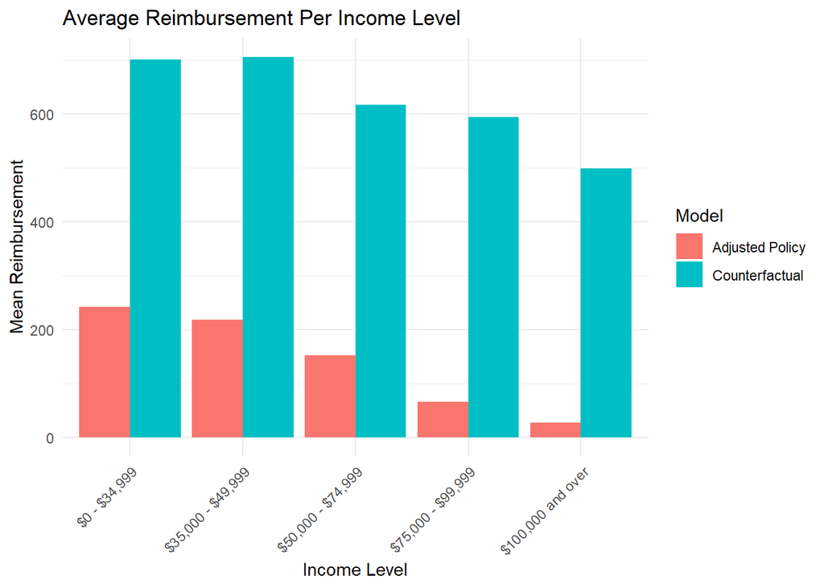

```r
# Comibing distributional analysis

adjusted_data1 <- simulated_data_custom_rate |>
  filter(income %in% c(11,12,22,23,24)) |>
  group_by(income) |>
  summarise(mean_reimbursement = mean(reimbursement)) |>
  mutate(
    income = case_when(
      income == 11 ~ "$0 - $34,999",
      income == 12 ~ "$35,000 - $49,999",
      income == 22 ~ "$50,000 - $74,999",
      income == 23 ~ "$75,000 - $99,999",
      income == 24 ~ "$100,000 and over"
    ),
    model = "Adjusted Policy"
  )


counterfactual_data1 <- simulated_data_cf |>
  filter(income %in% c(11,12,22,23,24)) |>
  group_by(income) |>
  summarise(mean_reimbursement = mean(reimbursement)) |>
  mutate(
    income = case_when(
      income == 11 ~ "$0 - $34,999",
      income == 12 ~ "$35,000 - $49,999",
      income == 22 ~ "$50,000 - $74,999",
      income == 23 ~ "$75,000 - $99,999",
      income == 24 ~ "$100,000 and over"
    ),
    model = "Counterfactual"
  )


comparison_data1 <- bind_rows(adjusted_data1, counterfactual_data1)


comparison_data1 <- comparison_data1 |>
  mutate(income = factor(income, levels = c("$0 - $34,999", "$35,000 - $49,999", "$50,000 - $74,999", "$75,000 - $99,999", "$100,000 and over")))


ggplot(comparison_data1, aes(x = income, y = mean_reimbursement, fill = model)) +
  geom_col(position = "dodge") +
  labs(
    title = "Average Reimbursement Per Income Level",
    x = "Income Level",
    y = "Mean Reimbursement",
    fill = "Model"
  ) +
  theme_minimal() +
  theme(axis.text.x = element_text(angle = 45, hjust = 1))
```

## 5. Conclusion

This study has important implications for policymakers in their decision-making process regarding predictive model selection and policy implementation. Policymakers must weigh factors such as the computational power and interpretability of different predictive models. For example, selecting a more sophisticated model may provide greater accuracy, but it could be more computationally intensive, requiring trade-offs between resource allocation and predictive precision.

When considering which version of a tax credit disbursement policy to implement, policymakers should focus on the broader societal impact, balancing economic efficiency against the need for equitable outcomes. A policy that is highly efficient may not always address the needs of the most vulnerable populations, so equity considerations should be integrated into the decision-making process, ensuring that the benefits of the policy are distributed fairly. Noticeably, the results from the counterfactual microsimulation suggests that people who are part of families with lower levels of income experience more work days missed due to illness and injury. Thus, family leave policies would generally support lower-income individuals and families and could arguably be viewed as a poverty alleviation strategy.

Looking to the future, there are several avenues to further enhance our analysis. With more time and processing power, incorporating a wider range of variables into the predictive model could improve accuracy and offer deeper insights. Additionally, expanding the microsimulation by integrating additional datasets that offer more granular geographic information would enable us to explore the effects of state-level policies on federal policy implementation, helping to better understand the nuances of policy interactions across different levels of government.

## References

Bartel, Ann, Maya Rossin-Slater, Christopher Ruhm, Meredith Slopen, and Jane Waldfogel. 2023a. “The Impacts of Paid Family and Medical Leave on Worker Health, Family Well-Being, and Employer Outcomes.” *Annual Review of Public Health* 44 (1): 429–43. https://doi.org/10.1146/annurev-publhealth-071521-025257.

———. 2023b. “The Impacts of Paid Family and Medical Leave on Worker Health, Family Well-Being, and Employer Outcomes.” *Annual Review of Public Health* 44 (1): 429–43. https://doi.org/10.1146/annurev-publhealth-071521-025257.

Blewett, Lynn A., Julia A. Rivera Drew, Miriam L. King, Kari C. W. Williams, Daniel Backman, Annie Chen, and Stephanie Richards. n.d. “IPUMS Health Surveys: National Health Interview Survey, Version 7.4.” https://doi.org/10.18128/D070.V7.4.

“Paid Family Leave Across OECD Countries.” 2022. https://bipartisanpolicy.org/explainer/paid-family-leave-across-oecd-countries/.

“State Paid Family Leave Laws Across the u.s.” 2024. https://bipartisanpolicy.org/explainer/state-paid-family-leave-laws-across-the-u-s/.

“Usual Weekly Earnings Summary.” 2025. https://www.bls.gov/news.release/wkyeng.nr0.htm.

“What’s on the Table? A Review of Federal Paid Family Leave Proposals.” 2025a. https://bipartisanpolicy.org/explainer/whats-on-the-table-a-review-of-federal-paid-family-leave-proposals/.

———. 2025b. https://bipartisanpolicy.org/explainer/whats-on-the-table-a-review-of-federal-paid-family-leave-proposals/.